# M5 Lab

Matthew Præstgaard

Spring 2024

# Lab Setup

## R packages

Load necessary packages.

```r
library(tidyverse)
library(readxl)
library(here)
library(car)
library(pROC)
library(glmnet)
library(glmtoolbox)
library(nnet)
library(jtools)
library(lintr)

lint_dir(path = here("BIOSTLabs", ".lintr"))
```

## Data management

The following data description comes from https://www.causeweb.org/tshs/hot-flashes/:

Menopause heralds a complex array of hormonal and physiologic changes, the most common of which is the feverish discomfort of hot flashes and often accompanied by sweating, chills and anxiety. The Mayo Clinic defines a hot flash as the “sudden feeling of warmth in the upper body which is usually most intense over the face, neck and chest”. Among women in the menopausal transition, hot flashes typically occur daily, are between 2-5 minutes duration, and can be expected to persist for more than 7 years Variations in hot flash experiences during the menopausal transition among different populations have been observed but are incompletely understood.

The aim of this lab is to explore race differences in self-reported hot flashes while considering other factors such as demographic information, BMI, reproductive hormone levels, and smoking.

```r
# read in the data
# make age group a factor variable (otherwise it will read as numeric in regression models)

hflash <- read_xlsx(here("Lab5", "hflash.xlsx")) %>%
  mutate(
    AgeGroup = factor(ageg - 1), # making dummy variable for age group with levels 0-3
    aagrp = factor(aagrp), # changing categorical variables to factors to be safe
    edu = factor(edu),
    d1 = factor(d1),
    f1a = factor(f1a),
    hotflash = factor(hotflash),
    bmi30 = factor(bmi30)
  ) %>%
  drop_na()

kable(head(hflash))
```

| pt | ageg | aagrp | edu | d1 | f1a | pcs12 | hotflash | bmi30 | estra | fsh | lh | testo | dheas | AgeGroup |
| --- | --- | --- | --- | --- | --- | --- | --- | --- | --- | --- | --- | --- | --- | --- |
| 3 | 2 | 0 | 1 | 0 | 0 | 56.80537 | 0 | 0 | 106.71 | 3.005 | 2.980 | 7.680 | 61.225 | 1 |
| 6 | 3 | 0 | 1 | 0 | 0 | 59.18338 | 0 | 0 | 31.25 | 11.195 | 5.760 | 11.930 | 104.920 | 2 |
| 7 | 1 | 0 | 1 | 0 | 1 | 57.73952 | 0 | 0 | 13.41 | 14.545 | 5.595 | 24.375 | 117.450 | 0 |
| 8 | 1 | 0 | 1 | 1 | 0 | 55.83575 | 1 | 0 | 10.64 | 5.530 | 2.260 | 8.280 | 36.850 | 0 |
| 9 | 2 | 0 | 1 | 0 | 1 | 55.89324 | 0 | 0 | 24.06 | 9.780 | 2.600 | 4.050 | 11.165 | 1 |
| 11 | 2 | 0 | 1 | 0 | 0 | 55.50097 | 0 | 1 | 26.32 | 7.960 | 3.570 | 15.995 | 76.780 | 1 |

# Data Analysis

## 1. Simple logistic regression model

**Fit a logistic regression model with race as the only predictor and self-reported hot flashes as the outcome.** **Is race significantly associated with the odds of self-reported hot flashes? Interpret the exponentiated coefficient for race in this model.**

```r
# fit logistic regression model with just race
glmRace <- glm(hotflash ~ aagrp, data = hflash, family = binomial(link = "logit"))
# print model output
summ(glmRace)
```

| Observations | 362 |
| --- | --- |
| Dependent variable | hotflash |
| Type | Generalized linear model |
| Family | binomial |
| Link | logit |

| χ²(1) | 7.83 |
| --- | --- |
| Pseudo-R² (Cragg-Uhler) | 0.03 |
| Pseudo-R² (McFadden) | 0.02 |
| AIC | 445.64 |
| BIC | 453.42 |

|  | Est. | S.E. | z val. | p |
| --- | --- | --- | --- | --- |
| (Intercept) | -1.11 | 0.17 | -6.62 | 0.00 |
| aagrp1 | 0.64 | 0.23 | 2.78 | 0.01 |

Standard errors: MLE

```r
sink("glm1.txt")
summary(glmRace)
```

```
##
## Call:
## glm(formula = hotflash ~ aagrp, family = binomial(link = "logit"),
##     data = hflash)
##
## Coefficients:
##             Estimate Std. Error z value Pr(>|z|)
## (Intercept)  -1.1127     0.1681  -6.618 3.64e-11 ***
## aagrp1        0.6389     0.2299   2.779  0.00545 **
## ---
## Signif. codes:  0 '***' 0.001 '**' 0.01 '*' 0.05 '.' 0.1 ' ' 1
##
## (Dispersion parameter for binomial family taken to be 1)
##
##     Null deviance: 449.47  on 361  degrees of freedom
## Residual deviance: 441.64  on 360  degrees of freedom
## AIC: 445.64
##
## Number of Fisher Scoring iterations: 4
```

```r
sink()
# exponentiated coefficient
exp(coef(glmRace))
```

```
## (Intercept)      aagrp1
##   0.3286713   1.8944199
```

Interpretation: With the p-value of race being **0.005**, we have evidence that it is significantly associated with the odds of self-reported hot flashes. The exponentiated coefficient of **1.89** means that African American women have about **1.894 times higher odds** of reporting hot flashes compared to Caucasian women, given that all other variables in the model are held constant.

## 2. Multiple logistic regression model

**Fit a logistic regression model for self-reported hot flashes (outcome) using race, age group,** **education, smoking status, pcs12, obesity status, estradiol, FSH, LH, testosterone, and** **dehydroepiandrosterone sulfate as predictors. What happens to the estimated association between** **race and log-odds of self-reported hot flashes after adjusting for these variables?**

```r
# fit logistic regression model with all predictors mentioned (not d1 (history of menopausal symptoms) or pt (patient id))
glmFull <- glm(hotflash ~ aagrp + AgeGroup + edu + f1a + pcs12 + bmi30 + estra + fsh + lh + testo + dheas, data = hflash, family = binomial(link = "logit"))

# print output
summ(glmFull)
```

| Observations | 362 |
| --- | --- |
| Dependent variable | hotflash |
| Type | Generalized linear model |
| Family | binomial |
| Link | logit |

| χ²(12) | 38.94 |
| --- | --- |
| Pseudo-R² (Cragg-Uhler) | 0.14 |
| Pseudo-R² (McFadden) | 0.09 |
| AIC | 436.53 |
| BIC | 487.12 |

|  | Est. | S.E. | z val. | p |
| --- | --- | --- | --- | --- |
| (Intercept) | -0.63 | 0.96 | -0.65 | 0.51 |
| aagrp1 | 0.32 | 0.26 | 1.24 | 0.21 |
| AgeGroup1 | 0.20 | 0.28 | 0.71 | 0.48 |
| AgeGroup2 | -0.42 | 0.37 | -1.14 | 0.26 |
| edu1 | -0.45 | 0.38 | -1.20 | 0.23 |
| f1a1 | 0.24 | 0.26 | 0.93 | 0.35 |
| pcs12 | -0.03 | 0.01 | -1.86 | 0.06 |
| bmi301 | 0.60 | 0.26 | 2.26 | 0.02 |
| estra | 0.00 | 0.00 | 0.19 | 0.85 |
| fsh | 0.10 | 0.04 | 2.62 | 0.01 |
| lh | 0.04 | 0.06 | 0.74 | 0.46 |
| testo | 0.00 | 0.01 | 0.30 | 0.76 |
| dheas | 0.00 | 0.00 | 0.31 | 0.75 |

Standard errors: MLE

```r
sink("glmFull.txt")
summary(glmFull)
```

```
##
## Call:
## glm(formula = hotflash ~ aagrp + AgeGroup + edu + f1a + pcs12 +
##     bmi30 + estra + fsh + lh + testo + dheas, family = binomial(link = "logit"),
##     data = hflash)
##
## Coefficients:
##               Estimate Std. Error z value Pr(>|z|)
## (Intercept) -0.6275298  0.9611552  -0.653  0.51383
## aagrp1       0.3228104  0.2599201   1.242  0.21425
## AgeGroup1    0.1957556  0.2754298   0.711  0.47725
## AgeGroup2   -0.4171634  0.3672060  -1.136  0.25594
## edu1        -0.4524099  0.3784447  -1.195  0.23191
## f1a1         0.2372549  0.2560549   0.927  0.35415
## pcs12       -0.0271167  0.0145811  -1.860  0.06293 .
## bmi301       0.5962006  0.2641805   2.257  0.02402 *
## estra        0.0008356  0.0045156   0.185  0.85320
## fsh          0.0950561  0.0363034   2.618  0.00883 **
## lh           0.0423625  0.0569154   0.744  0.45669
## testo        0.0035527  0.0118807   0.299  0.76492
## dheas        0.0007223  0.0022992   0.314  0.75342
## ---
## Signif. codes:  0 '***' 0.001 '**' 0.01 '*' 0.05 '.' 0.1 ' ' 1
##
## (Dispersion parameter for binomial family taken to be 1)
##
##     Null deviance: 449.47  on 361  degrees of freedom
## Residual deviance: 410.53  on 349  degrees of freedom
## AIC: 436.53
##
## Number of Fisher Scoring iterations: 4
```

```r
sink()

exp(coef(glmFull))
```

```
## (Intercept)      aagrp1   AgeGroup1   AgeGroup2        edu1        f1a1
##   0.5339090   1.3810035   1.2162297   0.6589132   0.6360934   1.2677643
##       pcs12      bmi301       estra         fsh          lh       testo
##   0.9732476   1.8152090   1.0008359   1.0997205   1.0432726   1.0035590
##       dheas
##   1.0007225
```

Response: After adjusting for all the added variables in the full model, the coefficient for race dropped from **0.639 to 0.323 (p=0.21)**.  
This indicates that, after adjustment, race is no longer significantly associated with self reported hot flashes.

## 3. Sensitivity and specificity

**Use the predicted probabilities from the fully adjusted model from part 2 to calculate the sensitivity** **and specificity using the thresholds 0.25, 0.5, and 0.75 to determine the predicted classes of each observation. What happens as you increase the threshold?**

```r
sink("part3.txt")

y <- glmFull$y
phat <- predict(glmFull, type = "response")

# threshold 1 (0.25)
thresh1 <- 0.25

yhat1 <- as.numeric(phat > thresh1)

data.frame(predicted = yhat1, observed = y) %>%
  xtabs(~ predicted + observed, data = .)
```

```
##          observed
## predicted   0   1
##         0 123  33
##         1 126  80
```

```r
# threshold 2 (0.5)
thresh2 <- 0.5

yhat2 <- as.numeric(phat > thresh2)

data.frame(predicted = yhat2, observed = y) %>%
  xtabs(~ predicted + observed, data = .)
```

```
##          observed
## predicted   0   1
##         0 237  87
##         1  12  26
```

```r
# threshold 3 (0.75)
thresh3 <- 0.75

yhat3 <- as.numeric(phat > thresh3)

data.frame(predicted = yhat3, observed = y) %>%
  xtabs(~ predicted + observed, data = .)
```

```
##          observed
## predicted   0   1
##         0 249 109
##         1   0   4
```

```r
sink()
```

Response:

As the threshold increases, sensitivity decreases while specificity increases.

## 4. ROC curve

**Construct an ROC curve for the model. Display the ROC curve below and comment on what you see.**

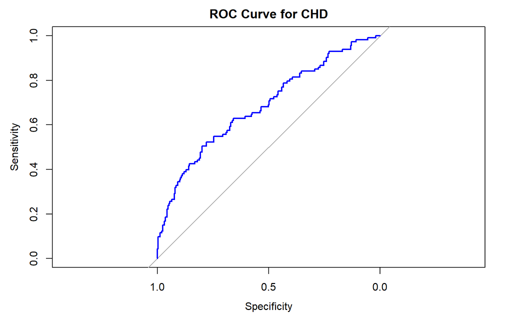

```r
# make roc curve
# remember that the roc_curve function from the pROC function needs the observed outcomes and the predicted probabilities from the model
roc_curve <- roc(response = y, predictor = phat)
# plot
plot(roc_curve, main = "ROC Curve for CHD", col = "blue")
```

```r
# ggroc(roc_curve)
```

What do you see? The curve is abvove random classifier performance but is not very close to the ideal top-left corner of the graph.

## 5. AUC

**Calculate the area under the ROC curve (AUC). Interpret this value in the context of how cases tend to be ranked by the model compared to controls.**

```r
# print the auc value
auc(roc_curve)
```

```
## Area under the curve: 0.6838
```

Interpretation: The AUC of 0.6838 indicates fair discrimination.

## 6. Shrinkage methods

```r
# cross-validation randomly splits the data, so setting the seed helps make sure you always get the same results (reproducibility)
set.seed(1234)

lassoX <- model.matrix(hotflash ~ aagrp + AgeGroup + edu + f1a + pcs12 + bmi30 + estra + fsh + lh + testo + dheas - 1, data = hflash)
lassoY <- hflash$hotflash

lasso <- cv.glmnet(x = lassoX, y = lassoY, family = "binomial", alpha = 1, type.measure = "auc")

lasso
```

```
##
## Call:  cv.glmnet(x = lassoX, y = lassoY, type.measure = "auc", family = "binomial",      alpha = 1)
##
## Measure: AUC
##
##     Lambda Index Measure      SE Nonzero
## min 0.0031    37  0.6317 0.03599      13
## 1se 0.0608     5  0.5964 0.02937       3
```

```r
max(lasso$cvm)
```

```
## [1] 0.6316903
```

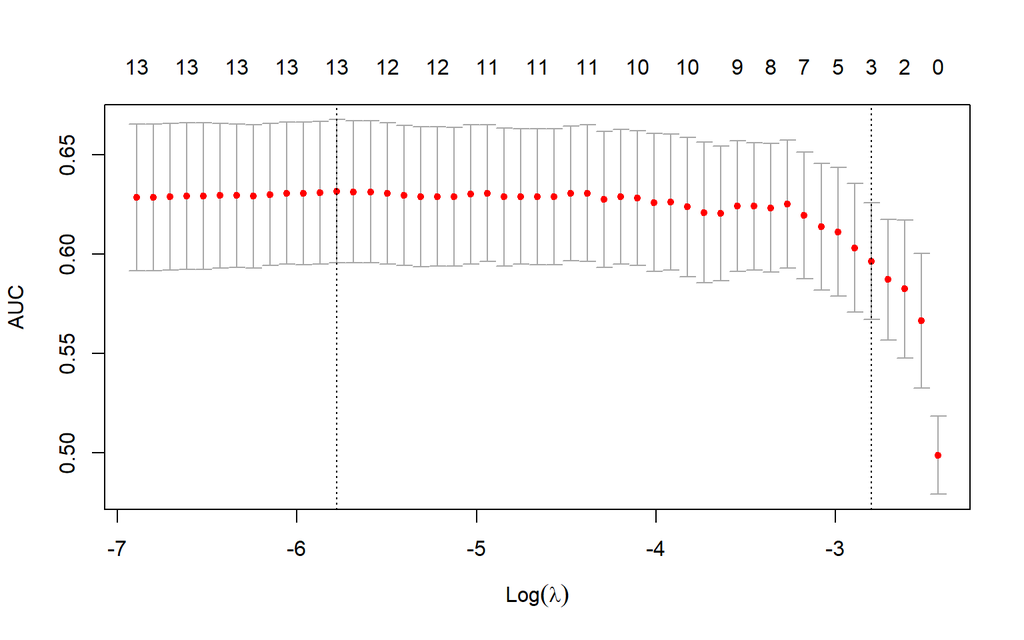

```r
plot(lasso)
```

```r
# using AUC as the measure of fit
# reminder: to change the metric used, set type.measure to the metric you want (auc, deviance, etc.)
# lasso

# show output
```

## 7. Which variables were kept?

**If we wanted to choose the biggest lambda penalty value that gives us an AUC within 1 standard error of the best AUC using the lasso method (lambda.1se),** **which covariates are kept in the model? Is race kept in the model? Is this consistent with what we saw in part 2?**

```r
# grab coefficients
coef_lasso_1se <- coef(lasso, "lambda.1se")
print(coef_lasso_1se)
```

```
## 14 x 1 sparse Matrix of class "dgCMatrix"
##                       s1
## (Intercept) -0.559583896
## aagrp0       .
## aagrp1       .
## AgeGroup1    .
## AgeGroup2    .
## edu1         .
## f1a1         .
## pcs12       -0.009436472
## bmi301       0.061589392
## estra        .
## fsh          0.027142985
## lh           .
## testo        .
## dheas        .
```

```r
# reminder, you can use coef(name_of_model, "lambda.1se")
```

Interpretation: The covariates remaining in the model are **pcs12, bmi30, and fsh**. Race is no longer part of the model. This is consistent with part 2 as the p-value for race was above the significance threshold.

## 8. Lasso with deviance

**Fit the lasso model again, but this time use deviance as the model fit metric.** **Compare the coefficients left in this model (again using “lambda.1se”) to the model using AUC to choose the best fitting model.** **What do you notice? Which method (metric) of choosing a model would you want to use if your main goal was classification?**

```r
# lasso with deviance
lassoDev <- cv.glmnet(lassoX, lassoY, family = "binomial", alpha = 1, type.measure = "deviance")

coef_lasso_dev <- coef(lassoDev, s = "lambda.1se")
print(coef_lasso_dev)
```

```
## 14 x 1 sparse Matrix of class "dgCMatrix"
##                       s1
## (Intercept) -0.608082557
## aagrp0       .
## aagrp1       .
## AgeGroup1    .
## AgeGroup2    .
## edu1         .
## f1a1         .
## pcs12       -0.007120011
## bmi301       0.010385883
## estra        .
## fsh          0.021229542
## lh           .
## testo        .
## dheas        .
```

```r
# compare covariates kept in the model
```

The covariates the in deviance model are the same as in the AUC model. Since they are retained in both models, it is suggested that they are robustly associated with the outcome of self-reported hot flashes.  
A metric using AUC would be more appropriate for the goal of classification.

## 9. Propensity Score Model

**Now suppose we’re more interested in statistical inference than prediction. Fit a propensity score model for race as the outcome using** **the remaining predictors from the model above. Which variables are related to race in the adjusted model?**

```r
# fit the propensity score model
glmProp <- glm(aagrp ~ pcs12 + bmi30 + fsh, family = binomial(link = "logit"), data = hflash)

# show model output
summ(glmProp)
```

| Observations | 362 |
| --- | --- |
| Dependent variable | aagrp |
| Type | Generalized linear model |
| Family | binomial |
| Link | logit |

| χ²(3) | 42.24 |
| --- | --- |
| Pseudo-R² (Cragg-Uhler) | 0.15 |
| Pseudo-R² (McFadden) | 0.08 |
| AIC | 466.70 |
| BIC | 482.27 |

|  | Est. | S.E. | z val. | p |
| --- | --- | --- | --- | --- |
| (Intercept) | 1.53 | 0.79 | 1.93 | 0.05 |
| pcs12 | -0.05 | 0.01 | -3.23 | 0.00 |
| bmi301 | 1.07 | 0.24 | 4.55 | 0.00 |
| fsh | 0.03 | 0.03 | 1.28 | 0.20 |

Standard errors: MLE

```r
sink("prop model.txt")
summary(glmProp)
```

```
##
## Call:
## glm(formula = aagrp ~ pcs12 + bmi30 + fsh, family = binomial(link = "logit"),
##     data = hflash)
##
## Coefficients:
##             Estimate Std. Error z value Pr(>|z|)
## (Intercept)  1.52634    0.79101   1.930  0.05366 .
## pcs12       -0.04564    0.01415  -3.226  0.00126 **
## bmi301       1.07026    0.23524   4.550 5.37e-06 ***
## fsh          0.03418    0.02667   1.282  0.20001
## ---
## Signif. codes:  0 '***' 0.001 '**' 0.01 '*' 0.05 '.' 0.1 ' ' 1
##
## (Dispersion parameter for binomial family taken to be 1)
##
##     Null deviance: 500.94  on 361  degrees of freedom
## Residual deviance: 458.70  on 358  degrees of freedom
## AIC: 466.7
##
## Number of Fisher Scoring iterations: 4
```

```r
sink()
```

Response: pcs12 and bmi30 are related to race in this model (**p=0.001 and p<0.001, respectively)

## 10. Adjusting for propensity scores

**Calculate the propensity scores using the model above. Use the propensity scores as a predictor, along with race, in a model for self-reported hot flashes.** **Interpret the coefficients in the model.**

*Note: you can save the propensity scores form the model above as a new column in the data to use in the regression model*

```r
# calculate and save propensity scores
hflash$propensity_score <- predict(glmProp, type = "response")

# fit model
glmRaceProp <- glm(hotflash ~ aagrp + propensity_score, family = binomial, data = hflash)

# print output
summ(glmRaceProp)
```

| Observations | 362 |
| --- | --- |
| Dependent variable | hotflash |
| Type | Generalized linear model |
| Family | binomial |
| Link | logit |

| χ²(2) | 22.12 |
| --- | --- |
| Pseudo-R² (Cragg-Uhler) | 0.08 |
| Pseudo-R² (McFadden) | 0.05 |
| AIC | 433.35 |
| BIC | 445.02 |

|  | Est. | S.E. | z val. | p |
| --- | --- | --- | --- | --- |
| (Intercept) | -2.30 | 0.37 | -6.21 | 0.00 |
| aagrp1 | 0.34 | 0.25 | 1.40 | 0.16 |
| propensity_score | 2.73 | 0.73 | 3.73 | 0.00 |

Standard errors: MLE

```r
sink("glmRaceProp.txt")
summary(glmRaceProp)
```

```
##
## Call:
## glm(formula = hotflash ~ aagrp + propensity_score, family = binomial,
##     data = hflash)
##
## Coefficients:
##                  Estimate Std. Error z value Pr(>|z|)
## (Intercept)       -2.3034     0.3708  -6.211 5.25e-10 ***
## aagrp1             0.3447     0.2465   1.399  0.16196
## propensity_score   2.7315     0.7318   3.732  0.00019 ***
## ---
## Signif. codes:  0 '***' 0.001 '**' 0.01 '*' 0.05 '.' 0.1 ' ' 1
##
## (Dispersion parameter for binomial family taken to be 1)
##
##     Null deviance: 449.47  on 361  degrees of freedom
## Residual deviance: 427.35  on 359  degrees of freedom
## AIC: 433.35
##
## Number of Fisher Scoring iterations: 4
```

```r
sink()
```

Interpretation: **Race**: coefficent = 0.345, p=0.16. This indicates that race is not a statistically significant predictor  
**Propensity Score**: coefficent = 2.732, p=<0.001. This means that the log odds of self-reported hot flashes increase by 2.732 for every increase in the propensity score.

## 11. Check Linearity

**Check the linearity condition (visually) for this model. Does it look like the linearity assumption holds?**

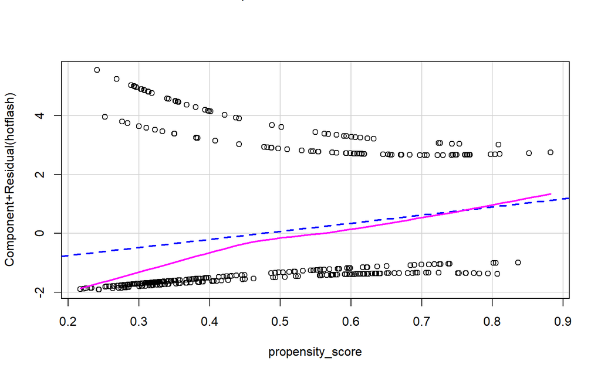

```r
# check linearity condition
residuals <- glmRaceProp$residuals

crPlots(glmRaceProp, terms = ~propensity_score)
```

Interpretation: The lines deviate from each other, implying violation of the linearity condition.

## 12. Propensity Score Quintiles

**Break the propensity scores into quintiles (5 groups of roughly equal size) and use this as a categorical predictor of self-reported hot flashes in addition to race.** **Interpret the coefficients in this model.**

```r
# split propensity scores into quintiles
# To cut the data into quintiles we can use the cut() function
# with breaks = quantile(your_propensity_scores, probs = (0:5)/5)
# make sure to use argument include.lowest = T

hflash <- hflash %>%
  mutate(pQuintiles = ntile(propensity_score, 5))

# fit model
glmQuint <- glm(hotflash ~ aagrp + factor(pQuintiles), data = hflash, family = binomial)

# print output
summ(glmQuint)
```

| Observations | 362 |
| --- | --- |
| Dependent variable | hotflash |
| Type | Generalized linear model |
| Family | binomial |
| Link | logit |

| χ²(5) | 19.98 |
| --- | --- |
| Pseudo-R² (Cragg-Uhler) | 0.08 |
| Pseudo-R² (McFadden) | 0.04 |
| AIC | 441.49 |
| BIC | 464.84 |

|  | Est. | S.E. | z val. | p |
| --- | --- | --- | --- | --- |
| (Intercept) | -1.46 | 0.30 | -4.86 | 0.00 |
| aagrp1 | 0.37 | 0.25 | 1.51 | 0.13 |
| factor(pQuintiles)2 | -0.10 | 0.42 | -0.25 | 0.81 |
| factor(pQuintiles)3 | 0.59 | 0.39 | 1.52 | 0.13 |
| factor(pQuintiles)4 | 0.73 | 0.39 | 1.89 | 0.06 |
| factor(pQuintiles)5 | 1.02 | 0.39 | 2.62 | 0.01 |

Standard errors: MLE

```r
sink("glmQuintiles.txt")
summary(glmQuint)
```

```
##
## Call:
## glm(formula = hotflash ~ aagrp + factor(pQuintiles), family = binomial,
##     data = hflash)
##
## Coefficients:
##                     Estimate Std. Error z value Pr(>|z|)
## (Intercept)          -1.4619     0.3007  -4.862 1.16e-06 ***
## aagrp1                0.3704     0.2461   1.505  0.13225
## factor(pQuintiles)2  -0.1024     0.4163  -0.246  0.80562
## factor(pQuintiles)3   0.5882     0.3865   1.522  0.12806
## factor(pQuintiles)4   0.7307     0.3862   1.892  0.05846 .
## factor(pQuintiles)5   1.0207     0.3895   2.621  0.00878 **
## ---
## Signif. codes:  0 '***' 0.001 '**' 0.01 '*' 0.05 '.' 0.1 ' ' 1
##
## (Dispersion parameter for binomial family taken to be 1)
##
##     Null deviance: 449.47  on 361  degrees of freedom
## Residual deviance: 429.49  on 356  degrees of freedom
## AIC: 441.49
##
## Number of Fisher Scoring iterations: 4
```

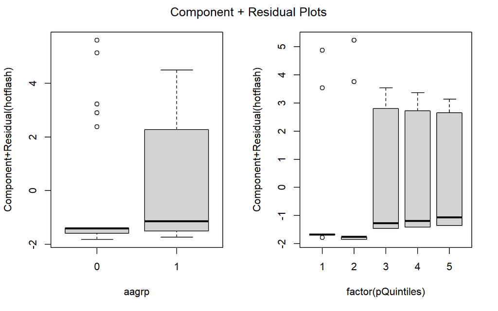

```r
sink()

crPlots(glmQuint)
```

Interpretation:  
Only the fifth quintile of the propensity scores was significantly associated with self-reported hot-flashes **(coef=1.02, p=0.01)**. This means that the fifth quintile of the propensity score has an increase of 1.02 in log odds of self-reported hot flashes compared to the first quintile.

## 13. Linearity Condition

**Do we need to check the linearity in the model above (using quintiles)? Why or why not? If yes, check the linearity condition (visually).**

```r
# if yes, check linearity condition
```

Answer: We do not need to check the linearity in the model. After changing the propensity score component from a continuous variable to quintiles (categorical), there is no longer a continous predictor in the model.

## 14. Compare Models

**Which model do you prefer of the four we’ve fit? The simple logistic regression model with just race,** **the multiple logistic regression adjusting for all covariates separately, the model adjusting for race and propensity score as a numeric variable,** **or the model adjusting for race and propensity score quintiles? Why?**

```r
predictedQuint <- predict(glmQuint, type = "response")
rocQuint <- roc(hflash$hotflash, predictedQuint)
auc(rocQuint)
```

```
## Area under the curve: 0.6412
```

Response here: I prefer the model using propensity score quintiles. It’s simpler than the full model but adjusts for confounders better than the simple model. Using the quintiles for the propensity scores also solves the problem of non-linearity that is present in the model using p-scores as a continuous predictor.

## 15. Summary

**Summarize your findings. Was race associated with hot flashes? What about when other covariates were adjusted for?** **Did the model do a good job classifying those with and without hot flashes?**

In the simple model, race appeared to be a significant predictor of self-reported hot flashes, but upon adjusting for other variables, that was found to no longer be the case. Adjusting for confounders and then filtering them through cross-validation revealed BMI30, pcs12, and fsh were found to be significant predictors. pcs12 and bmi30 were found to be associated with race using a propensity score model. As the linearity condition was not met using p-scores as a continuous variable, they were broken up into categorical quintiles. With an AUC of 0.6412, the chosen model has fair classification performance.